# IODS course project

Ilari Hotti

# About the project

This is a course about data science using open source tools and open scientific practices in general,

Tools used in this course:

- R and RStudio
- RMarkdown, and other R packages
- GitHub

[Link to my IODS Github repository](https://github.com/ilarjod/IODS-project/)

In the first week I got all the tools working and made this html page.

# Regression and model validation

*This week I learned about importing and wrangling data and simple analysis*

### Importing data

The data is from a survey from a Finnish introductory statistics course regarding learning.

I originally imported a dataset with 183 observations and 60 variables and manipulated it as advised into a tighter one, which I will be analysing now.

```r
library(dplyr)
library(ggplot2)
library(GGally)
lrn14 <- read.table("data/learning2014.txt")
str(lrn14)
```

```
## 'data.frame':    166 obs. of  7 variables:
##  $ gender  : Factor w/ 2 levels "F","M": 1 2 1 2 2 1 2 1 2 1 ...
##  $ age     : int  53 55 49 53 49 38 50 37 37 42 ...
##  $ attitude: num  3.7 3.1 2.5 3.5 3.7 3.8 3.5 2.9 3.8 2.1 ...
##  $ deep    : num  3.58 2.92 3.5 3.5 3.67 ...
##  $ stra    : num  3.38 2.75 3.62 3.12 3.62 ...
##  $ surf    : num  2.58 3.17 2.25 2.25 2.83 ...
##  $ points  : int  25 12 24 10 22 21 21 31 24 26 ...
```

```r
summary(lrn14)
```

```
##  gender       age           attitude          deep            stra
##  F:110   Min.   :17.00   Min.   :1.400   Min.   :1.583   Min.   :1.250
##  M: 56   1st Qu.:21.00   1st Qu.:2.600   1st Qu.:3.333   1st Qu.:2.625
##          Median :22.00   Median :3.200   Median :3.667   Median :3.188
##          Mean   :25.51   Mean   :3.143   Mean   :3.680   Mean   :3.121
##          3rd Qu.:27.00   3rd Qu.:3.700   3rd Qu.:4.083   3rd Qu.:3.625
##          Max.   :55.00   Max.   :5.000   Max.   :4.917   Max.   :5.000
##       surf           points
##  Min.   :1.583   Min.   : 7.00
##  1st Qu.:2.417   1st Qu.:19.00
##  Median :2.833   Median :23.00
##  Mean   :2.787   Mean   :22.72
##  3rd Qu.:3.167   3rd Qu.:27.75
##  Max.   :4.333   Max.   :33.00
```

It now contains 166 observations and 7 variables. The variables are:

```
* gender      Man (56) or Female (110)
* age         Range 17-55, median 22.
* attitude    Measures attitude towards learning statistics
* deep        Deep learning
* stra        Strategic approach
* surf        Surface learning
* points      Points from exam
```

### Graphical overview

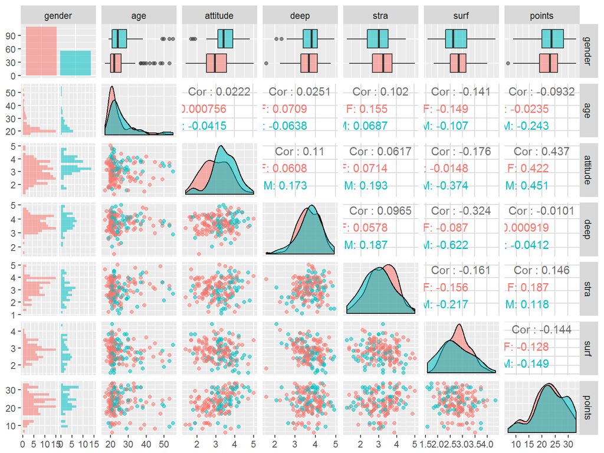

```r
ggpairs(lrn14, mapping = aes(col = gender, alpha = 0.3), lower = list(combo = wrap("facethist", bins = 20)))
```

The highest correlation to `points` seems to be with variable `attitude`.

### Fitting a regression model

Let’s try to model `points` with 3 variables. I choose `age`, `attitude` and `stra`.

```r
model1 <- lm(points ~ age + attitude + stra, data = lrn14)
summary(model1)
```

```
##
## Call:
## lm(formula = points ~ age + attitude + stra, data = lrn14)
##
## Residuals:
##      Min       1Q   Median       3Q      Max
## -18.1149  -3.2003   0.3303   3.4129  10.7599
##
## Coefficients:
##             Estimate Std. Error t value Pr(>|t|)
## (Intercept) 10.89543    2.64834   4.114 6.17e-05 ***
## age         -0.08822    0.05302  -1.664   0.0981 .
## attitude     3.48077    0.56220   6.191 4.72e-09 ***
## stra         1.00371    0.53434   1.878   0.0621 .
## ---
## Signif. codes:  0 '***' 0.001 '**' 0.01 '*' 0.05 '.' 0.1 ' ' 1
##
## Residual standard error: 5.26 on 162 degrees of freedom
## Multiple R-squared:  0.2182, Adjusted R-squared:  0.2037
## F-statistic: 15.07 on 3 and 162 DF,  p-value: 1.07e-08
```

Only `attitude` seems to be correlated enough (other are P<0.1, attitude p<0.001), so let’s dump the other two from the model.

```r
model2 <- lm(points ~ attitude , data = lrn14)
summary(model2)
```

```
##
## Call:
## lm(formula = points ~ attitude, data = lrn14)
##
## Residuals:
##      Min       1Q   Median       3Q      Max
## -16.9763  -3.2119   0.4339   4.1534  10.6645
##
## Coefficients:
##             Estimate Std. Error t value Pr(>|t|)
## (Intercept)  11.6372     1.8303   6.358 1.95e-09 ***
## attitude      3.5255     0.5674   6.214 4.12e-09 ***
## ---
## Signif. codes:  0 '***' 0.001 '**' 0.01 '*' 0.05 '.' 0.1 ' ' 1
##
## Residual standard error: 5.32 on 164 degrees of freedom
## Multiple R-squared:  0.1906, Adjusted R-squared:  0.1856
## F-statistic: 38.61 on 1 and 164 DF,  p-value: 4.119e-09
```

R-squared: the percentage of the response variable variation that is explained by a linear model.

So `attitude` is a statistically significant variable. It explains ~19% of the variability in `points`.

Let’s visualize the model.

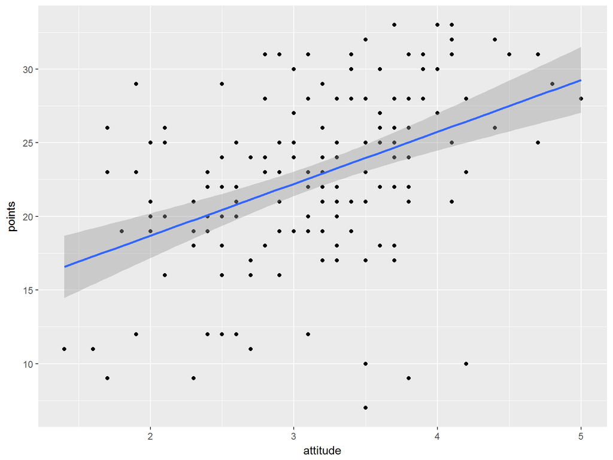

```r
qplot(attitude, points, data = lrn14) + geom_smooth(method = "lm")
```

### Model diagnostics

When fitting linear model, we are assuming:

- The errors are normally distributed
- The errors are not correlated
- The errors have constant variance
- The size of a given error does not depend on the explanatory variables

We can evaluate the assumptions by examining how the residuals behave.

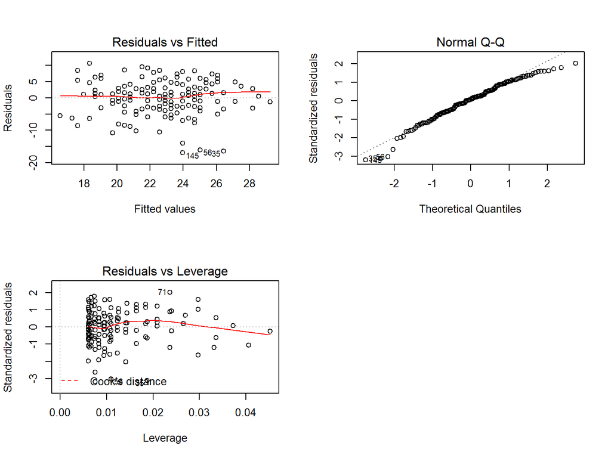

```r
par(mfrow = c(2,2))
plot(model2, which = c(1,2,5))
```

There is no pattern in the vs fitted plot and in the Q-Q plot the residuals are on the line, which means the residuals are normally distributed. There are no significant outliers in the residuals vs leverage plot so our model assumptions are ok.

### Conclusion

Positive attitude gives you more points!

# Logistic regression

```r
library("tidyverse")
library("ggplot2")
library("dplyr")
library(GGally)
alc <- read.table("data/alc.txt")
Palette <- c("#555555", "#009E73", "#56B4E9", "#E69F00", "#F0E442", "#0072B2", "#D55E00", "#CC79A7")
```

I got some survey data from [here](https://archive.ics.uci.edu/ml/datasets/STUDENT+ALCOHOL+CONSUMPTION).

The survey questions are about students’ studying and free time from two different classes. Data has no identifier for the students but it includes many background variables that can be used to combine the data.

In the data wrangling part I also created the high alcohol consumptions variable, which will studied further in the analysis.

```r
glimpse(alc)
```

```
## Observations: 382
## Variables: 35
## $ school     <fctr> GP, GP, GP, GP, GP, GP, GP, GP, GP, GP, GP, GP, GP...
## $ sex        <fctr> F, F, F, F, F, M, M, F, M, M, F, F, M, M, M, F, F,...
## $ age        <int> 18, 17, 15, 15, 16, 16, 16, 17, 15, 15, 15, 15, 15,...
## $ address    <fctr> U, U, U, U, U, U, U, U, U, U, U, U, U, U, U, U, U,...
## $ famsize    <fctr> GT3, GT3, LE3, GT3, GT3, LE3, LE3, GT3, LE3, GT3, ...
## $ Pstatus    <fctr> A, T, T, T, T, T, T, A, A, T, T, T, T, T, A, T, T,...
## $ Medu       <int> 4, 1, 1, 4, 3, 4, 2, 4, 3, 3, 4, 2, 4, 4, 2, 4, 4, ...
## $ Fedu       <int> 4, 1, 1, 2, 3, 3, 2, 4, 2, 4, 4, 1, 4, 3, 2, 4, 4, ...
## $ Mjob       <fctr> at_home, at_home, at_home, health, other, services...
## $ Fjob       <fctr> teacher, other, other, services, other, other, oth...
## $ reason     <fctr> course, course, other, home, home, reputation, hom...
## $ nursery    <fctr> yes, no, yes, yes, yes, yes, yes, yes, yes, yes, y...
## $ internet   <fctr> no, yes, yes, yes, no, yes, yes, no, yes, yes, yes...
```

[output cut: 22 more lines]

### Examining the variables

I’ll examine students’ alcohol consumption habits with 4 other variables.

I choose address (Urban or Rural), famsize (bigger than 3 or not), Pstatus (parents living together or not) and goout (how much the student goes out).

Living area type could be somehow correlated with alcohol consumption but don’t know which way.

I would assume parents living apart would imply higher alcohol consumption.

Going out should be positively correlated obviously.

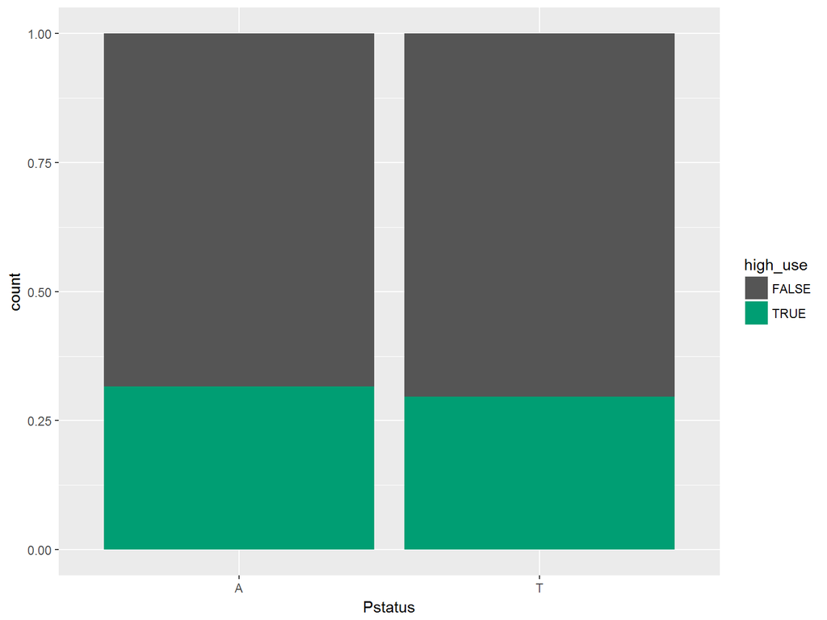

```r
g3 <- ggplot(alc, aes(x = Pstatus, fill = high_use)) + geom_bar(position="fill")
g3 + scale_fill_manual(values=Palette)
```

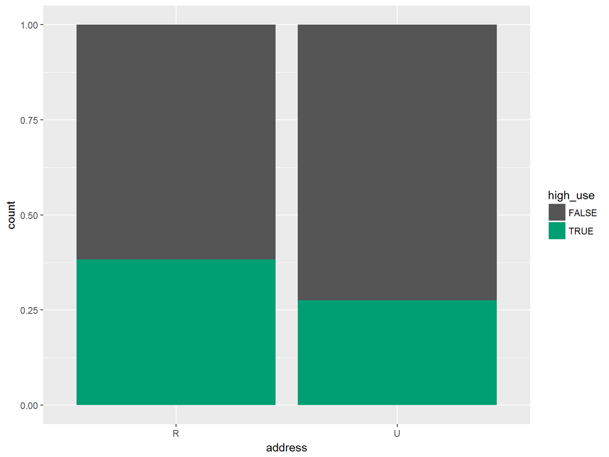

```r
g4 <- ggplot(alc, aes(x = address, fill = high_use)) + geom_bar(position="fill")
g4 + scale_fill_manual(values=Palette)
```

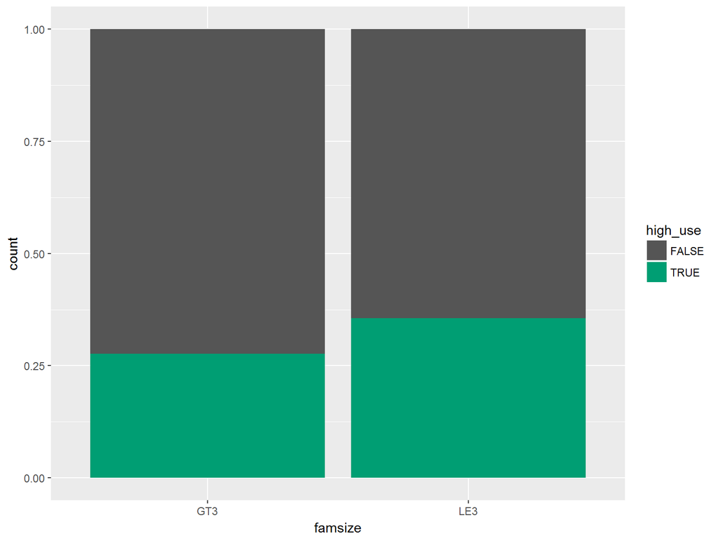

```r
g5 <- ggplot(alc, aes(x = famsize, fill = high_use)) + geom_bar(position="fill")
g5 + scale_fill_manual(values=Palette)
```

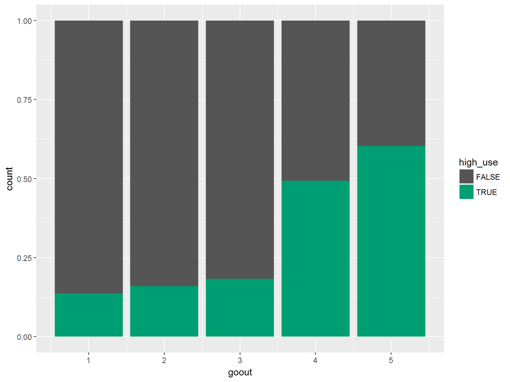

```r
g6 <- ggplot(alc, aes(x = goout, fill = high_use)) + geom_bar(position="fill")
g6 + scale_fill_manual(values=Palette)
```

```r
table(high_use = alc$high_use, address = alc$address) %>% prop.table() %>% addmargins()
```

```
##         address
## high_use          R          U        Sum
##    FALSE 0.13089005 0.57068063 0.70157068
##    TRUE  0.08115183 0.21727749 0.29842932
##    Sum   0.21204188 0.78795812 1.00000000
```

```r
table(high_use = alc$high_use, parents_living_together = alc$Pstatus) %>% prop.table() %>% addmargins()
```

```
##         parents_living_together
## high_use          A          T        Sum
##    FALSE 0.06806283 0.63350785 0.70157068
##    TRUE  0.03141361 0.26701571 0.29842932
##    Sum   0.09947644 0.90052356 1.00000000
```

```r
table(high_use = alc$high_use, familysize = alc$famsize) %>% addmargins() %>% prop.table()
```

```
##         familysize
## high_use        GT3        LE3        Sum
##    FALSE 0.13154450 0.04384817 0.17539267
##    TRUE  0.05039267 0.02421466 0.07460733
##    Sum   0.18193717 0.06806283 0.25000000
```

```r
table(high_use = alc$high_use, outgoingness = alc$goout) %>% addmargins()  %>% prop.table()
```

```
##         outgoingness
## high_use           1           2           3           4           5
##    FALSE 0.012434555 0.054973822 0.067408377 0.026832461 0.013743455
##    TRUE  0.001963351 0.010471204 0.015052356 0.026178010 0.020942408
##    Sum   0.014397906 0.065445026 0.082460733 0.053010471 0.034685864
##         outgoingness
## high_use         Sum
##    FALSE 0.175392670
##    TRUE  0.074607330
##    Sum   0.250000000
```

Living area and family size seem to have something to do with with high alcohol consumption and there’s high correlation with going out more.

### Fitting a logistic model and predictions

```r
m <- glm(high_use ~ address + Pstatus + famsize + goout, data = alc, family = "binomial")

summary(m)
```

```
##
## Call:
## glm(formula = high_use ~ address + Pstatus + famsize + goout,
##     family = "binomial", data = alc)
##
## Deviance Residuals:
##     Min       1Q   Median       3Q      Max
## -1.6006  -0.8076  -0.5978   1.0949   2.4129
##
## Coefficients:
##             Estimate Std. Error z value Pr(>|z|)
## (Intercept)  -2.8881     0.5949  -4.855 1.20e-06 ***
## addressU     -0.7584     0.2933  -2.585  0.00973 **
## PstatusT     -0.1128     0.4088  -0.276  0.78268
## famsizeLE3    0.4323     0.2691   1.606  0.10827
## goout         0.7913     0.1180   6.707 1.99e-11 ***
## ---
## Signif. codes:  0 '***' 0.001 '**' 0.01 '*' 0.05 '.' 0.1 ' ' 1
##
## (Dispersion parameter for binomial family taken to be 1)
##
##     Null deviance: 465.68  on 381  degrees of freedom
## Residual deviance: 406.88  on 377  degrees of freedom
## AIC: 416.88
##
## Number of Fisher Scoring iterations: 4
```

```r
coef(m)
```

```
## (Intercept)    addressU    PstatusT  famsizeLE3       goout
##  -2.8881308  -0.7583813  -0.1127540   0.4322526   0.7913017
```

So going out(p<0.001) and address area (p<0.01) are correlated with high alcohol consumption. Parents’ living arrangements and size of the family have really no effect.

Let’s calculate the odds ratios and confidence intervals etc.

```r
OR <- coef(m) %>% exp

CI <- exp(confint(m))

cbind(OR, CI)
```

```
##                     OR      2.5 %    97.5 %
## (Intercept) 0.05568019 0.01661415 0.1723069
## addressU    0.46842403 0.26305868 0.8338070
## PstatusT    0.89337038 0.40827321 2.0508068
## famsizeLE3  1.54072418 0.90578508 2.6084279
## goout       2.20626657 1.76160258 2.8002343
```

```r
probabilities <- predict(m, type = "response")

# add the predicted probabilities to 'alc'
alc <- mutate(alc, probability = probabilities)

# use the probabilities to make a prediction of high_use
alc <- mutate(alc, prediction = probability > 0.5)

# tabulate the target variable versus the predictions
table(high_use = alc$high_use, prediction = alc$prediction)
```

```
##         prediction
## high_use FALSE TRUE
##    FALSE   243   25
##    TRUE     73   41
```

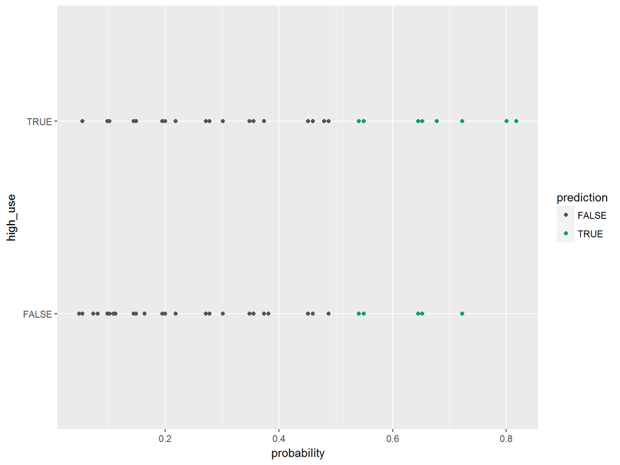

```r
# initialize a plot of 'high_use' versus 'probability' in 'alc'
g <- ggplot(alc, aes(x = probability, y = high_use, col = prediction)) + geom_point()
g + scale_colour_manual(values=Palette)
```

```r
# tabulate the target variable versus the predictions
table(high_use = alc$high_use, prediction = alc$prediction) %>% prop.table()  %>% addmargins()
```

```
##         prediction
## high_use      FALSE       TRUE        Sum
##    FALSE 0.63612565 0.06544503 0.70157068
##    TRUE  0.19109948 0.10732984 0.29842932
##    Sum   0.82722513 0.17277487 1.00000000
```

```r
loss_func <- function(class, prob) {
  n_wrong <- abs(class - prob) > 0.5
  mean(n_wrong)
}

# call loss_func to compute the average number of wrong predictions in the (training) data
loss_func(class = alc$high_use, prob = alc$probability)
```

```
## [1] 0.2565445
```

```r
library(boot)
cv <- cv.glm(data = alc, cost = loss_func, glmfit = m, K = 10)

# average number of wrong predictions in the cross validation
cv$delta[1]
```

```
## [1] 0.2565445
```

# Clustering and classification

```r
library("tidyverse")
library("ggplot2")
library("dplyr")
library("MASS")
library("corrplot")

data("Boston")
Palette <- c("#555555", "#009E73", "#56B4E9", "#E69F00", "#F0E442", "#0072B2", "#D55E00", "#CC79A7")
```

This week’s data is about housing values in [Boston](https://stat.ethz.ch/R-manual/R-devel/library/MASS/html/Boston.html).

```r
str(Boston)
```

```
## 'data.frame':    506 obs. of  14 variables:
##  $ crim   : num  0.00632 0.02731 0.02729 0.03237 0.06905 ...
##  $ zn     : num  18 0 0 0 0 0 12.5 12.5 12.5 12.5 ...
##  $ indus  : num  2.31 7.07 7.07 2.18 2.18 2.18 7.87 7.87 7.87 7.87 ...
##  $ chas   : int  0 0 0 0 0 0 0 0 0 0 ...
##  $ nox    : num  0.538 0.469 0.469 0.458 0.458 0.458 0.524 0.524 0.524 0.524 ...
##  $ rm     : num  6.58 6.42 7.18 7 7.15 ...
##  $ age    : num  65.2 78.9 61.1 45.8 54.2 58.7 66.6 96.1 100 85.9 ...
##  $ dis    : num  4.09 4.97 4.97 6.06 6.06 ...
##  $ rad    : int  1 2 2 3 3 3 5 5 5 5 ...
##  $ tax    : num  296 242 242 222 222 222 311 311 311 311 ...
##  $ ptratio: num  15.3 17.8 17.8 18.7 18.7 18.7 15.2 15.2 15.2 15.2 ...
##  $ black  : num  397 397 393 395 397 ...
##  $ lstat  : num  4.98 9.14 4.03 2.94 5.33 ...
##  $ medv   : num  24 21.6 34.7 33.4 36.2 28.7 22.9 27.1 16.5 18.9 ...
```

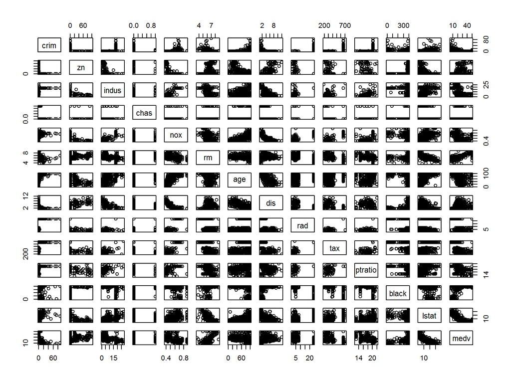

```r
pairs(Boston)
```

So there are 506 observations and 14 variables. The plot is not very informative. It’s easier to spot high correlations with a correlogram, where a bigger and darker ball indicates higher correlation.

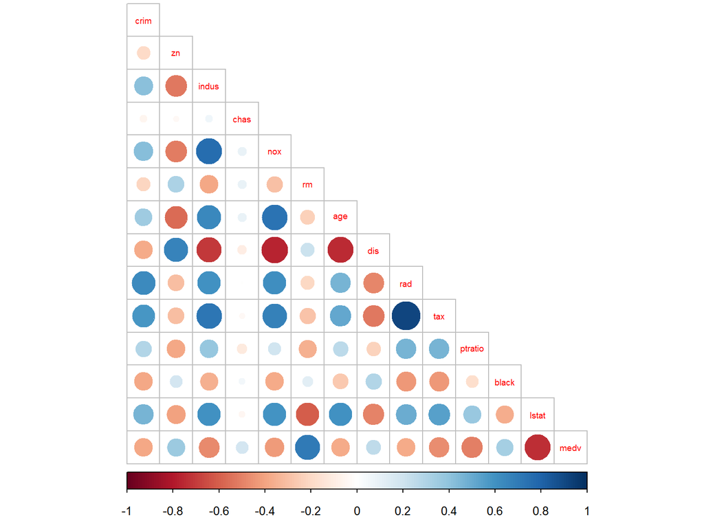

```r
cor_matrix<-cor(Boston) %>% round(digits = 2)
corrplot(cor_matrix, method="circle", type="lower", cl.pos = "b", tl.pos = "d", tl.cex = 0.6)
```

Scaling here means subtracting the column means from the corresponding columns and dividing the difference with standard deviation:

$$scaled(x) = \frac{x-means(x)}{sd(x)}$$

```r
# center and standardize variables
boston_scaled <- scale(Boston)

# summaries of the scaled variables
summary(boston_scaled)
```

```
##       crim                 zn               indus
##  Min.   :-0.419367   Min.   :-0.48724   Min.   :-1.5563
##  1st Qu.:-0.410563   1st Qu.:-0.48724   1st Qu.:-0.8668
##  Median :-0.390280   Median :-0.48724   Median :-0.2109
##  Mean   : 0.000000   Mean   : 0.00000   Mean   : 0.0000
##  3rd Qu.: 0.007389   3rd Qu.: 0.04872   3rd Qu.: 1.0150
##  Max.   : 9.924110   Max.   : 3.80047   Max.   : 2.4202
##       chas              nox                rm               age
##  Min.   :-0.2723   Min.   :-1.4644   Min.   :-3.8764   Min.   :-2.3331
##  1st Qu.:-0.2723   1st Qu.:-0.9121   1st Qu.:-0.5681   1st Qu.:-0.8366
##  Median :-0.2723   Median :-0.1441   Median :-0.1084   Median : 0.3171
##  Mean   : 0.0000   Mean   : 0.0000   Mean   : 0.0000   Mean   : 0.0000
##  3rd Qu.:-0.2723   3rd Qu.: 0.5981   3rd Qu.: 0.4823   3rd Qu.: 0.9059
##  Max.   : 3.6648   Max.   : 2.7296   Max.   : 3.5515   Max.   : 1.1164
##       dis               rad               tax             ptratio
##  Min.   :-1.2658   Min.   :-0.9819   Min.   :-1.3127   Min.   :-2.7047
##  1st Qu.:-0.8049   1st Qu.:-0.6373   1st Qu.:-0.7668   1st Qu.:-0.4876
##  Median :-0.2790   Median :-0.5225   Median :-0.4642   Median : 0.2746
##  Mean   : 0.0000   Mean   : 0.0000   Mean   : 0.0000   Mean   : 0.0000
##  3rd Qu.: 0.6617   3rd Qu.: 1.6596   3rd Qu.: 1.5294   3rd Qu.: 0.8058
##  Max.   : 3.9566   Max.   : 1.6596   Max.   : 1.7964   Max.   : 1.6372
##      black             lstat              medv
##  Min.   :-3.9033   Min.   :-1.5296   Min.   :-1.9063
##  1st Qu.: 0.2049   1st Qu.:-0.7986   1st Qu.:-0.5989
##  Median : 0.3808   Median :-0.1811   Median :-0.1449
##  Mean   : 0.0000   Mean   : 0.0000   Mean   : 0.0000
##  3rd Qu.: 0.4332   3rd Qu.: 0.6024   3rd Qu.: 0.2683
##  Max.   : 0.4406   Max.   : 3.5453   Max.   : 2.9865
```

```r
# change the object to data frame
boston_scaled <- as.data.frame(boston_scaled)

# save the scaled crim as scaled_crim
scaled_crim <- boston_scaled$crim

# summary of the scaled_crim
summary(scaled_crim)
```

```
##      Min.   1st Qu.    Median      Mean   3rd Qu.      Max.
## -0.419400 -0.410600 -0.390300  0.000000  0.007389  9.924000
```

```r
# create a quantile vector of crim and print it
bins <- quantile(scaled_crim)


crime <- cut(scaled_crim, breaks = bins, include.lowest = TRUE, label = c("low", "med_low", "med_high", "high"))

# remove original crim from the dataset
boston_scaled <- dplyr::select(boston_scaled, -crim)

# add the new categorical value to scaled data
boston_scaled <- data.frame(boston_scaled, crime)
```

Next I sample 80% of the observations for the train set and leave the remaining 20% for the test set.

```r
# number of rows in the Boston dataset
n <- nrow(boston_scaled)
# choose randomly 80% of the rows
ind <- sample(n,  size = n * 0.8)
# create train set
train <- boston_scaled[ind,]

# create test set
test <- boston_scaled[-ind,]

# save the correct classes from test data
correct_classes <- test$crime

# linear discriminant analysis
lda.fit <- lda(crime ~ ., data = train)
```

In my LDA (linear disrciminant analysis) the categorical crime variable is the target and all the other variables are predictor variables. I fit the lda model to the train set and try to predict the classes in the test set.

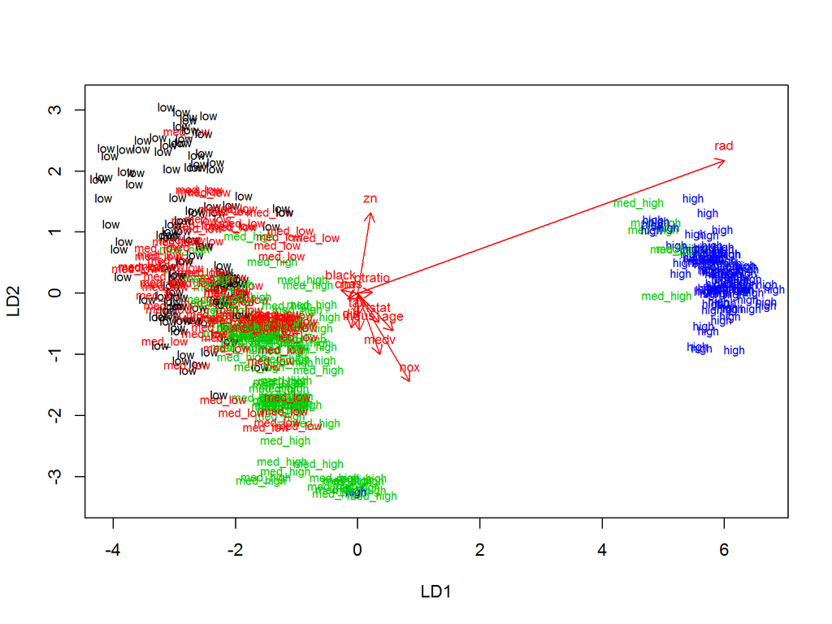

```r
# the function for lda biplot arrows
lda.arrows <- function(x, myscale = 1, arrow_heads = 0.1, color = "red", tex = 0.75, choices = c(1,2)){
  heads <- coef(x)
  arrows(x0 = 0, y0 = 0,
         x1 = myscale * heads[,choices[1]],
         y1 = myscale * heads[,choices[2]], col=color, length = arrow_heads)
  text(myscale * heads[,choices], labels = row.names(heads),
       cex = tex, col=color, pos=3)
}

# target classes as numeric
classes <- as.numeric(train$crime)

# plot the lda results
plot(lda.fit, dimen = 2, col = classes, pch = classes)
lda.arrows(lda.fit, myscale = 2)
```

We can see that variable rad (index of accessibility to radial highways) clearly has something to do with the high crime cluster.

```r
lda.pred <- predict(lda.fit, newdata = test)

# cross tabulate the results
table(correct = correct_classes, predicted = lda.pred$class)
```

```
##           predicted
## correct    low med_low med_high high
##   low       13       7        1    0
##   med_low    8      14        7    0
##   med_high   0      10       16    0
##   high       0       0        0   26
```

The model works OK, even though some classes are predicted wrong but that is to be expected.

Moving on to k-means clustering. I recall the data and scale it to examine distance properties of the data. I check out the euclidean (normal way of understanding distances) and manhattan (as if you lived in manhattan and had to move via the grid of streets) distances.

```r
data("Boston")
Bostonscaled <- scale(Boston)
# euclidean distance matrix
dist_eu <- dist(Bostonscaled)
# look at the summary of the distances
summary(dist_eu)
```

```
##    Min. 1st Qu.  Median    Mean 3rd Qu.    Max.
##  0.1343  3.4620  4.8240  4.9110  6.1860 14.4000
```

```r
# manhattan distance matrix
dist_man <- dist(Bostonscaled, method = "manhattan")

# look at the summary of the distances
summary(dist_man)
```

```
##    Min. 1st Qu.  Median    Mean 3rd Qu.    Max.
##  0.2662  8.4830 12.6100 13.5500 17.7600 48.8600
```

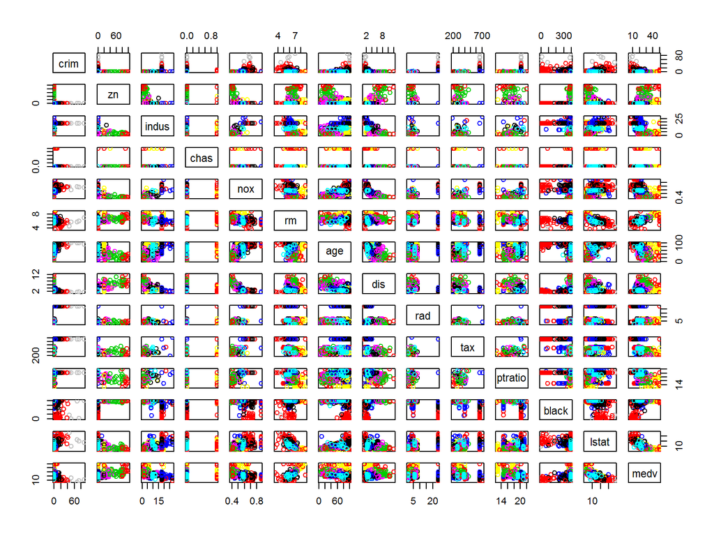

```r
# k-means clustering
km <-kmeans(dist_eu, centers = 10 )

# plot the Boston dataset with clusters
pairs(Boston, col = km$cluster)
```

Boston data with clusters. Then I think research what is an optimal amount of clusters for the data.

```r
# MASS, ggplot2 and Boston dataset are available
set.seed(27)

# euclidean distance matrix
dist_eu <- dist(Boston)

# determine the number of clusters
k_max <- 10

# calculate the total within sum of squares
twcss <- sapply(1:k_max, function(k){kmeans(dist_eu, k)$tot.withinss})
```

WCSS (within cluster sum of squares) drops the most at 2 centers.

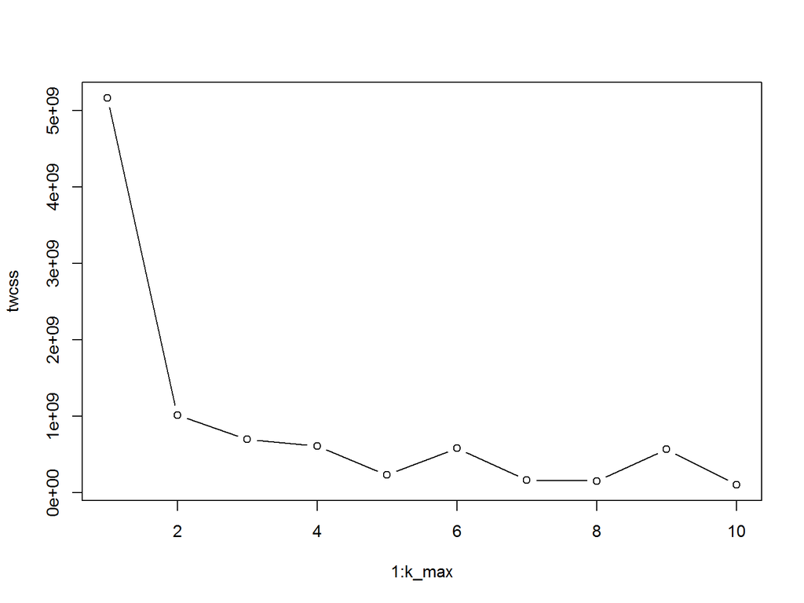

```r
# visualize the results
plot(1:k_max, twcss, type='b')
```

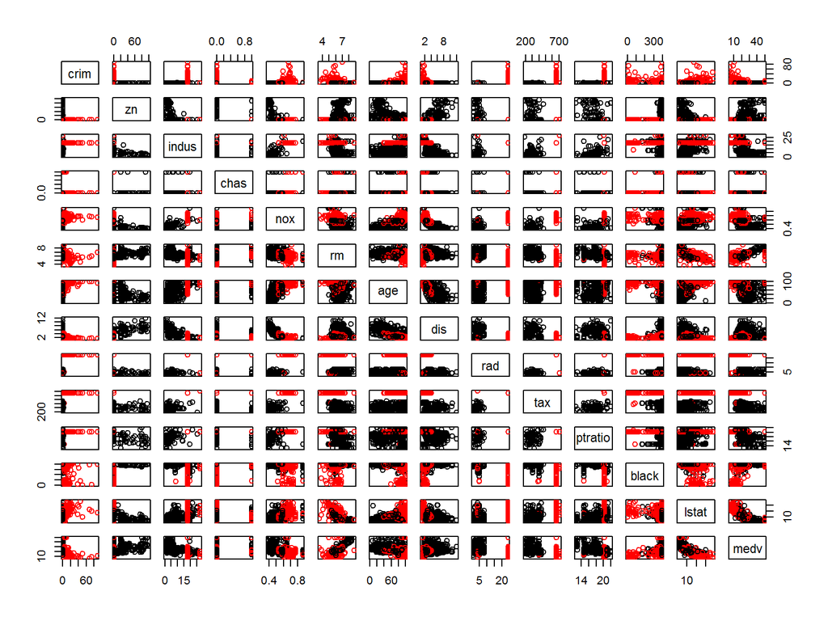

```r
# k-means clustering
km <-kmeans(dist_eu, centers = 2)

# plot the Boston dataset with clusters
pairs(Boston, col = km$cluster)
```

(Again very poor plot but i cannot do better.)

# Dimensionality reduction techniques

```r
library("tidyverse")
library("ggplot2")
library("dplyr")
library("MASS")
library("corrplot")
library("GGally")


human <- read.table("data/human_.txt")
```

This week we’ll be working with some Human Development Index (HDI) data. The data was wrangled from 2 datasets: HDI and GII (gender inequality index). I combined the datasets and reduced the observations and variables to 155 and 8 respectively to clean the data from missing values etc. I also combined some variables to create more interesting ones.

So the data has now countries for rownnames and and 8 variables describing their human development.

```r
summary(human)
```

```
##  edu_2nd_ratio      lab_ratio         life_exp        edu_exp
##  Min.   :0.1717   Min.   :0.1857   Min.   :49.00   Min.   : 5.40
##  1st Qu.:0.7264   1st Qu.:0.5984   1st Qu.:66.30   1st Qu.:11.25
##  Median :0.9375   Median :0.7535   Median :74.20   Median :13.50
##  Mean   :0.8529   Mean   :0.7074   Mean   :71.65   Mean   :13.18
##  3rd Qu.:0.9968   3rd Qu.:0.8535   3rd Qu.:77.25   3rd Qu.:15.20
##  Max.   :1.4967   Max.   :1.0380   Max.   :83.50   Max.   :20.20
##    GNI.capita        mat_mort        adol_birth       parl_rep_f
##  Min.   :   581   Min.   :   1.0   Min.   :  0.60   Min.   : 0.00
##  1st Qu.:  4198   1st Qu.:  11.5   1st Qu.: 12.65   1st Qu.:12.40
##  Median : 12040   Median :  49.0   Median : 33.60   Median :19.30
##  Mean   : 17628   Mean   : 149.1   Mean   : 47.16   Mean   :20.91
##  3rd Qu.: 24512   3rd Qu.: 190.0   3rd Qu.: 71.95   3rd Qu.:27.95
##  Max.   :123124   Max.   :1100.0   Max.   :204.80   Max.   :57.50
```

- edu_2nd_ratio : ratio of females/males in secondary education
- lab_ratio : ratio of females/males in the labour force
- life_exp : life expectancy at birth
- edu_exp : expected years of education
- GNI.capita : gross national income per capita
- mat_mort : maternal mortality
- adol_birth : adolescent birth rate
- parl_rep_f : female representatives in the parliament

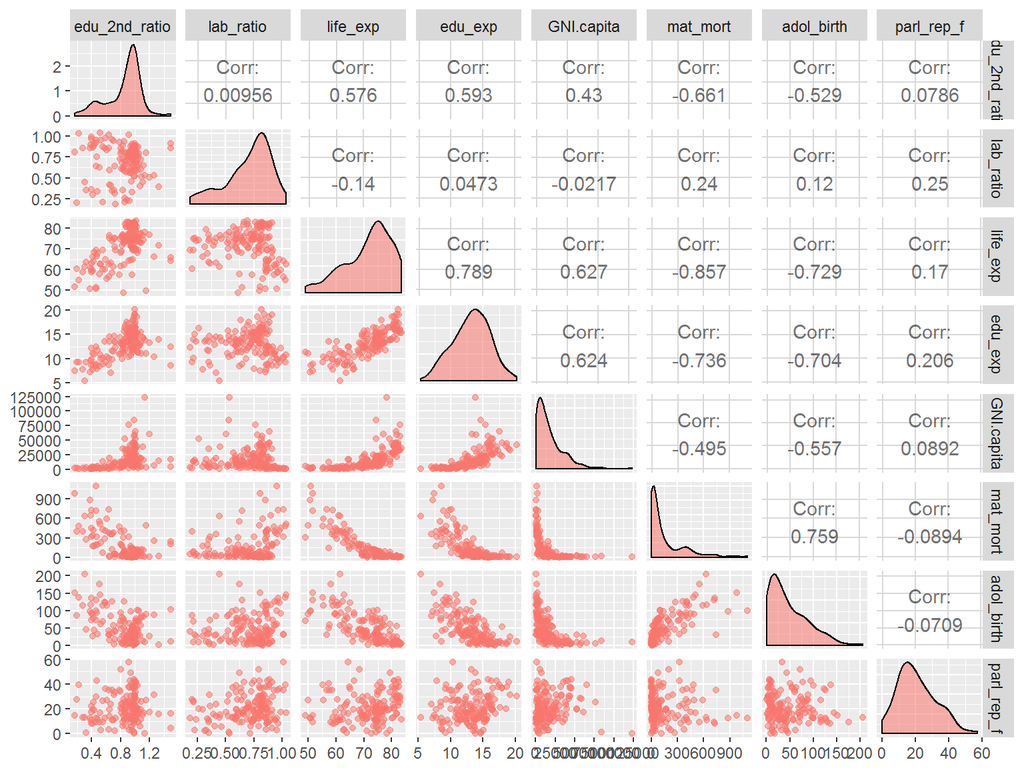

```r
ggpairs(human, aes(col="black", alpha=0.1))
```

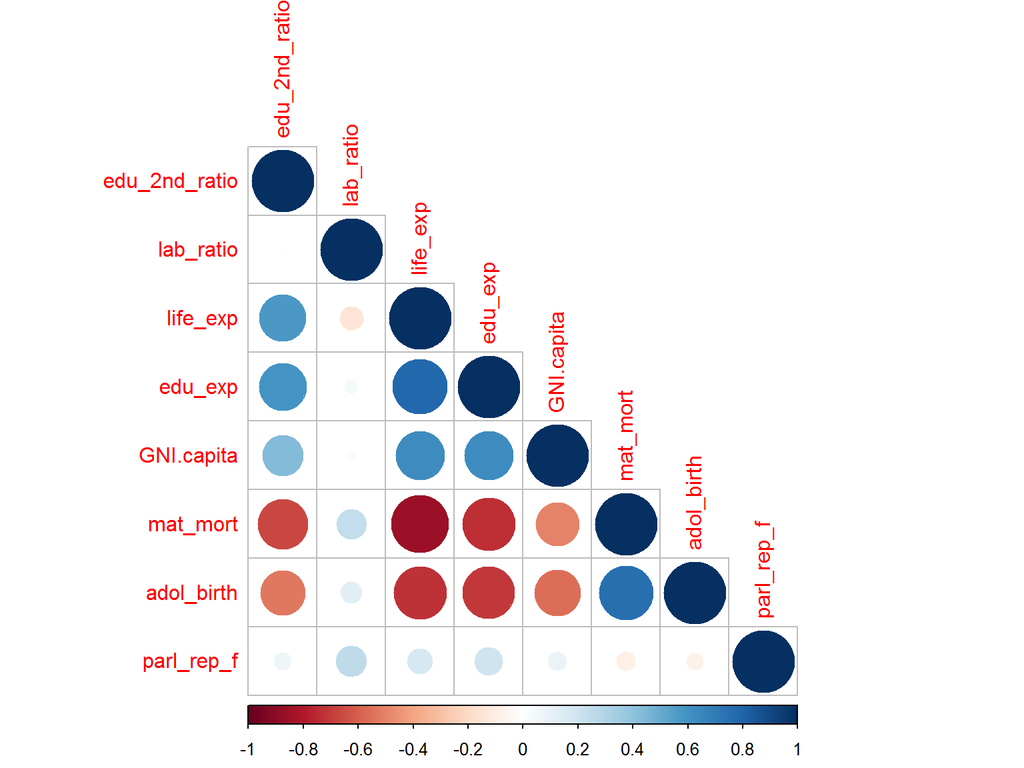

```r
corrplot(cor(human), type="lower")
```

There some high correlations in the data. Most are very obvious, for example maternal mortality having high negative correlation with life expectancy and positive with adolescent birth.

Then I’ll do the principal component analysis (PCA).

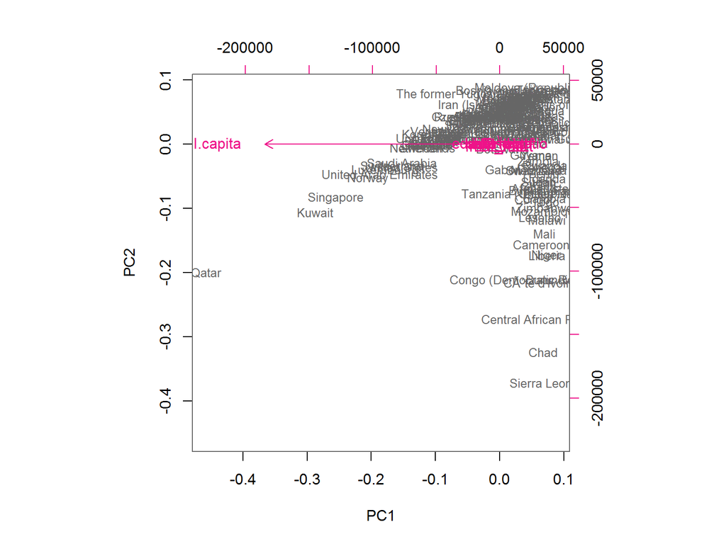

```r
# perform principal component analysis (with the SVD method)
pca_human <- prcomp(human)

# draw a biplot of the principal component representation and the original variables
biplot(pca_human, choices = 1:2, cex = c(0.8, 1), col = c("grey40", "deeppink2"))
```

Without standardization the biplot seems to be useless so let’s try that.

```r
# standardize the variables
human_std <- scale(human)

# print out summaries of the standardized variables
summary(human_std)
```

```
##  edu_2nd_ratio       lab_ratio          life_exp          edu_exp
##  Min.   :-2.8189   Min.   :-2.6247   Min.   :-2.7188   Min.   :-2.7378
##  1st Qu.:-0.5233   1st Qu.:-0.5484   1st Qu.:-0.6425   1st Qu.:-0.6782
##  Median : 0.3503   Median : 0.2316   Median : 0.3056   Median : 0.1140
##  Mean   : 0.0000   Mean   : 0.0000   Mean   : 0.0000   Mean   : 0.0000
##  3rd Qu.: 0.5958   3rd Qu.: 0.7350   3rd Qu.: 0.6717   3rd Qu.: 0.7126
##  Max.   : 2.6646   Max.   : 1.6632   Max.   : 1.4218   Max.   : 2.4730
##    GNI.capita         mat_mort         adol_birth        parl_rep_f
##  Min.   :-0.9193   Min.   :-0.6992   Min.   :-1.1325   Min.   :-1.8203
##  1st Qu.:-0.7243   1st Qu.:-0.6496   1st Qu.:-0.8394   1st Qu.:-0.7409
##  Median :-0.3013   Median :-0.4726   Median :-0.3298   Median :-0.1403
##  Mean   : 0.0000   Mean   : 0.0000   Mean   : 0.0000   Mean   : 0.0000
##  3rd Qu.: 0.3712   3rd Qu.: 0.1932   3rd Qu.: 0.6030   3rd Qu.: 0.6127
##  Max.   : 5.6890   Max.   : 4.4899   Max.   : 3.8344   Max.   : 3.1850
```

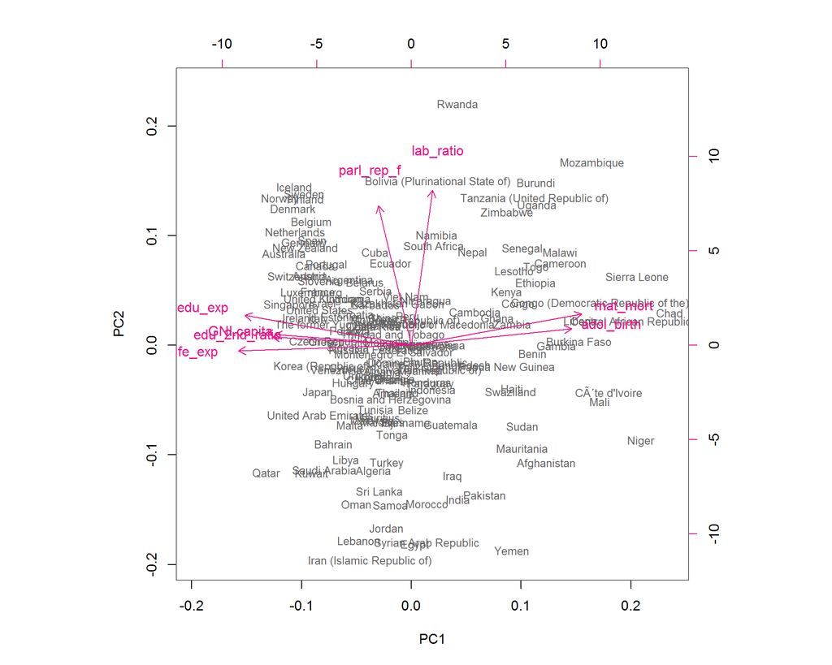

```r
# perform principal component analysis (with the SVD method)
pca_human <- prcomp(human_std)

# draw a biplot of the principal component representation and the original variables
biplot(pca_human, choices = 1:2, cex = c(0.8, 1), col = c("grey40", "deeppink2"))
```